# Bioengenharia de Água e Solo e Soluções Baseadas na Natureza

Análise Ambiental · Aula 14.1

Prof. Dr. Luiz Diego Vidal Santos

## Abertura Visão Geral da Aula

**01 · SbN e Bioengenharia:** Soluções Baseadas na Natureza (IUCN) e Bioengenharia na Análise Ambiental.

**02 · Princípios Físicos:** rugosidade de Manning ($n$), tensão cisalhante ($\tau_0$) e coesão radicular ($c_r$).

**03 · Zoneamento:** intervenções na vertente e na microbacia (Cabeceira $\rightarrow$ Taludes $\rightarrow$ Tálvegue).

**04 · Paliçadas:** funcionamento hidráulico (*check-dams* permeáveis) e formação de cunhas de sedimento.

**05 · Técnicas Aplicadas:** barreiras vivas (Capim-Vetiver), biomantas, geocompostos e retentores.

**06 · Margens Fluviais:** estabilização bioengenheira e integração com a sucessão ecológica no PRAD.

Objetivo da Aula Dissipação hidráulica e reforço radicular

Compreender como as **Soluções Baseadas na Natureza (SbN)** e a **Bioengenharia de Água e Solo** atuam na recuperação de áreas degradadas (PRAD), integrando dissipação de energia hidráulica, retenção de sedimentos e reforço mecânico radicular na escala da vertente e da bacia hidrográfica.

SbN · IUCN 2020 Manning & Mohr-Coulomb Check-Dams Biomantas & Vetiver

# Soluções Baseadas na Natureza e Bioengenharia

## SbN e Princípios Soluções Baseadas na Natureza e bioengenharia

IUCN, 2020 Soluções Baseadas na Natureza (SbN)

Envolvem proteção, manejo e restauração de ecossistemas para enfrentar desafios sociais, gerando benefícios simultâneos à biodiversidade e ao bem-estar humano.

Abordagem híbrida Bioengenharia de Água e Solo

Combina vegetação e elementos construtivos para funções hidráulicas, mecânicas e ecológicas. Pode integrar SbN quando atende aos objetivos e critérios pertinentes.

Comparar alternativas pela adequação ao local, durabilidade, manutenção, custo do ciclo de vida e efeitos a montante e jusante. Estruturas vegetadas, obras minerais e soluções híbridas têm desempenhos condicionados pelo projeto e pelo ambiente — evitar percentuais universais de economia ou promessas sem monitoramento.

## Princípios Hidráulica (Manning) e Resistência Radicular (Mohr-Coulomb)

**Equação de Manning (rugosidade $n$ e velocidade $v$):**

$$v = \frac{1}{n}\,R_h^{2/3}\,S^{1/2}$$

Cobertura vegetal e serapilheira elevam $n$, reduzindo a velocidade do escoamento e favorecendo a infiltração.

**Mohr-Coulomb com coesão radicular ($c_r$):**

$$\tau = c' + c_r + \sigma' \tan\phi'$$

Raízes atuam como fibras na matriz do solo, acrescentando $c_r$ à coesão efetiva ($c'$) e ao atrito ($\sigma'\tan\phi'$).

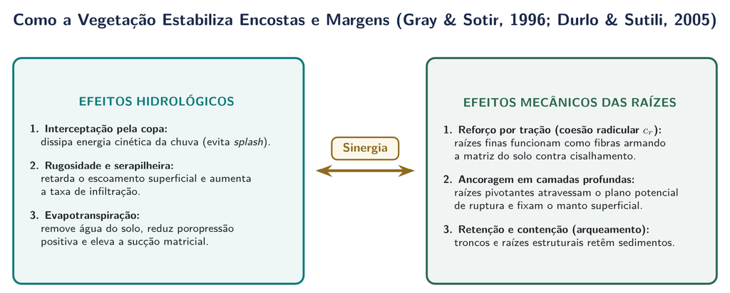

Efeitos hidrológicos e mecânicos das raízes na estabilização de encostas e margens fluviais.

Como a vegetação estabiliza encostas e margens (Gray & Sotir, 1996; Durlo & Sutili, 2005) Sinergia entre interceptação, rugosidade, sucção matricial por evapotranspiração, coesão radicular ($c_r$) e ancoragem

## Mecanismos Mecanismos e condições de funcionamento

| Função | Processo | O que avaliar |
| --- | --- | --- |
| **Proteção superficial** | Cobertura reduz impacto de gotas e modifica o escoamento | Continuidade, contato e falhas da cobertura |
| **Retenção** | Estruturas alteram transporte e armazenamento | Sedimento retido, transbordamento e erosão lateral |
| **Reforço radicular** | Raízes mobilizam resistência e modificam a água no solo | Espécie, estabelecimento, distribuição e plano de ruptura |
| **Recuperação ecológica** | Recolonização e melhoria do habitat | Sobrevivência, regeneração, diversidade e invasoras |

Aumentar rugosidade não garante redução da tensão em qualquer situação, pois geometria e lâmina também mudam. Raízes não eliminam por si só poropressão, erosão basal ou ruptura profunda.

# Zoneamento de Intervenções e Paliçadas

## Paliçadas Mecanismo Hidrossedimentológico de Paliçadas Permeáveis em Série

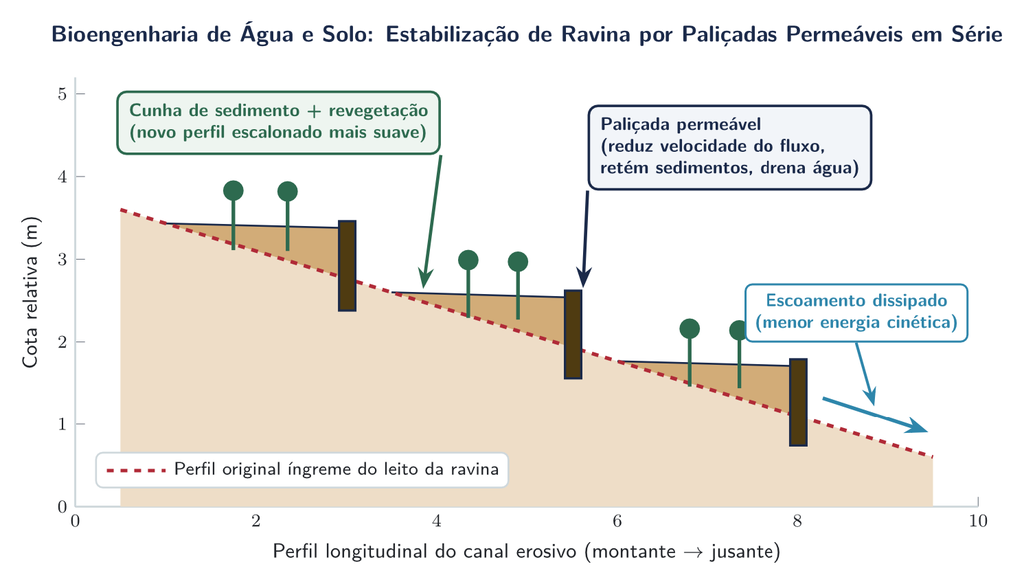

Perfil longitudinal esquemático do funcionamento de paliçadas permeáveis (check-dams) no controle de ravinas e voçorocas.

Estabilização de ravina por paliçadas permeáveis em série (*check-dams*) Dissipação do escoamento, retenção gradual de cunhas de sedimento e revegetação do perfil escalonado

## Zoneamento Planejar intervenções na vertente e na microbacia

**01 · Diagnóstico de fluxos:** identificar fontes de água e sedimento, caminhos de fluxo e receptores.

**02 · Segurança e controle:** proteger pessoas e interromper práticas que mantêm a degradação.

**03 · Montante:** avaliar controle do escoamento a montante **com saída segura**.

**04 · Compartimentos:** tratar cabeceira, taludes, fundo e margens conforme o processo ativo.

**05 · Cobertura:** implantar proteção superficial e revegetação com cronograma sazonal.

**06 · Manutenção:** inspecionar após eventos extremos e ajustar intervenções.

Cuidado hidráulico Não transferir o problema

Terraços, desvios, retaludamento, drenos e barramentos exigem avaliação específica.

**Regra crítica:** não concentrar água em outro setor nem infiltrar junto a uma encosta instável sem investigar o efeito na poropressão.

# Tecnologias Bioengenheiras Aplicadas

## Técnicas Vegetação, biomantas, geocompostos e retentores

Seleção vegetal Espécies nativas e Capim-Vetiver

- Selecionar espécies compatíveis com clima, solo, disponibilidade hídrica e objetivo; priorizar adequação ecológica e avaliar risco de invasão.
- **Vetiver** pode formar barreiras densas, mas profundidade e resistência das raízes dependem de cultivar, idade e sítio.

Obras de superfície Biomantas e retentores

- **Biomantas** precisam de contato íntimo com o solo, fixação e tratamento das bordas.
- **Retentores** requerem continuidade, capacidade hidráulica e pontos seguros de descarga.
- Não adotar valor único de tração radicular para toda a encosta; a fase de implantação exige proteção e manutenção próprias.

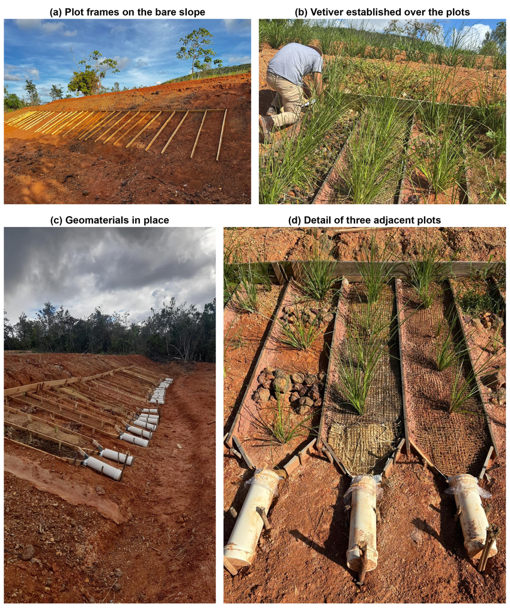

Parcelas experimentais de bioengenharia com quadros em talude exposto, implantação de capim-vetiver e geocompostos antierosivos em campo.

Ensaio de campo com geocompostos e vetiver em talude Parcelas experimentais monitoradas: implantação em solo exposto, estabelecimento vegetal e coletores de escoamento

## Margens Fluviais Margens fluviais: combinar processos e técnicas

01 · Soluções combinadas Repertório técnico

Enrocamento vegetado, feixes vivos, estacas e parede Krainer são alternativas conforme material, geometria e regime hidráulico.

02 · Itens a verificar Projeto e hidráulica

Erosão do pé, fundação, filtros, níveis de cheia, velocidade de fluxo, acesso, conexão ripária e efeitos sobre o canal.

03 · Limite da revegetação Solapamento basal

Revegetar a face não resolve necessariamente o solapamento basal. A escolha deve considerar dinâmica fluvial, competência profissional, licenças e manutenção.

# Síntese e Referências

## Monitoramento Recuperação: definir metas e critérios de revisão

| Dimensão | Indicador | Registro |
| --- | --- | --- |
| **Superfície** | Cobertura e falhas | Parcelas e fotografias repetidas |
| **Erosão** | Recuo e mudanças de seção | Referências estáveis e incerteza |
| **Estruturas** | Deformação, obstrução e erosão lateral | Inspeção após eventos |
| **Vegetação** | Sobrevivência e regeneração | Amostragem e época |
| **Conexão com o rio** | Sedimentos e qualidade da água | Chuva, vazão e pontos comparáveis |

Definir metas por contexto e responsáveis por manutenção. Estabilidade e recuperação são hipóteses a testar ao longo do tempo.

## Referências Referências de projeto e avaliação

Bibliografia da Aula SbN e Bioengenharia de Solos

- IUCN. **Global Standard for Nature-based Solutions**. 2020.
- GRAY, D. H.; SOTIR, R. B. **Biotechnical and Soil Bioengineering Slope Stabilization**. 1996.
- DURLO, M. A.; SUTILI, F. J. **Bioengenharia: manejo biotécnico de cursos de água**. 2014.
- NRCS. [Soil Bioengineering for Streambank and Shoreline Protection](https://directives.nrcs.usda.gov/sites/default/files2/1720531900/Chapter%2016%20-%20Soil%20Bioengineering%20for%20Streambank%20and%20Shoreline%20Protection.pdf). 2021.

Na Análise Ambiental, integrar processos, território e prioridades do PRAD. Dimensionamento e ensaios também são aprofundados em Bioengenharia de Solos.